# Exploración del índice de afloramiento en Matapalito

Veronica Valverde

12/2/2020

# Sobre la investigacion y este rmd

Mi ivestigacion se centra en los patrones de movimiento de tortugas carey juveniles (*Eretmochelys imbricata*) que viven en la bahia Matapalito. Esta es una pequena bahia localizada en el Pacifico Norte de costa Rica. Mide aproximadamente 1km de diametro y tiene gran diversidad de habitats (desde arrecifes de coral hasta pastos marinos). En el 2014 se identifico como un sitio de alimentacion importante para las tortugas carey en el Pacifico Oriental (Heidemeyer, Arauz-vargas, and López-agüero 2014). Esta es una de las poblaciones de tortugas marinas en mayor peligro de extincion y de las que ha sido menos estudiadas (Mortimer and Donnelly 2008). La bahia Matapalito se convierte en un sitio de crucial importancia, ya que al encontrar esta y otras especies de tortugas en peligro de extincion y en estadios vitales para su supervivencia como lo son las etapas juveniles. Por esto, entender mejor la ecologia y el comportamiento de las torugas en esta bahia puede ayudar a tomar mejore medidas de manejo. Sin embargo, en esta bahia en particular se unen factores importantes que pueden afectar los patrones de movimiento de las tortugas. En esta bahia se dan afloramientos costeros temporales, los cuales son eventos oceanograficos donde el viento causa un desplazamiento de las aguas superficiales y una surgencia de aguas profundas recas en nutrientes y bajas en oxigeno y temperatura. Estos eventos se dan etre Diciembre y Abril de cada año, y su efecto en los ecosistemas locales es cpoco conocido. Antes de poder analizar como las condiciones ambientales afectan los patrones de movimiento (lo que es uno de los principales objetivos de mi tesis de maestria), se debe de iniciar por analizar los patrones de estas condiciones ambientales para ver como cambian con el afloramiento. En este caso nos vamos a enfocar en las temperaturas del agua, que son uno de los factores que mas cambian con estos eventos y son de las mas faciles de medir. Ademas de que es muy util como proxy del indice de afloraminto (el cual indica la intensidad del evento).

### ¿Hay diferencia entre estimar el indice de afloramiento con Temperatura Superficial Local y con Temperatura medida insitu en la bahia Matapalito?

# Variables

- Temperatura Superficial Local
- Temperatura Superficial de Referencia (fuera del area de afloramiento)
- Temperatura medida in situ

En este caso no se hara un analisis causal, sino que se utilizaran datos diarios de la temperatura superficial del agua de un sitio local y de un sitio de referencia para sacar el indice de afloramiento semanal y mensual. Se haran dos estimaciones de esto, una es usando los datos locales de temperatura satelital y otro usando los datos de temperatura registrada in situ. Luego se hara un t Student (o su equivalente no parametrico segun la distribucion de los datos) para ver si hay una diferencia entre estos metodos.

# Datos

Los datos se pueden encontrar en [este repositorio](https://github.com/verovalcan/Proyecto_Final.git)

Los datos de temperatura superficial se descargaron de las bases de datos satelitales libres de la NOAA

Datos del satelite:

```
Multi-scale Ultra-high Resolution (MUR) SST Analysis fv04.1, Global, 0.01°, 2002-present, Daily
Dataset ID: jplMURSST41
https://coastwatch.pfeg.noaa.gov/erddap/griddap/jplMURSST41.html
```

Se descargaron datos de un poligono en cada area para evitar perder datos por cobertura de nubes (cuando hay nubes el dato de una hora no se toma, por lo que tomar datos de varios puntos/pixeles y promediarlos disminuye la perdida de datos), para un periodo de 2 años y medio (de 2018-01-01 al 2020-06-30). Las coordenadas de ambos poligonos son las siguientes:

Coordenadas Matapalito x= 10.934380°, y=-85.784776° x= 10.953925°, y=-85.812438°

Coordenadas referencia x= 10.580319°, y=-98.709226° x= 10.607619°, y=-98.740472°

Los datos de temperatura del agua in situ se tomaron con un HOBO fijo en la bahia (coordenadas 10.935816°, -85.795906°), programado para hacer las mediciones cada 5 min. Fue instalado el 2018-09-08 y extraido el 2020-08-07.

# Análisis de los datos

Primero cargar las librerias necesarias

en las siguientes secciones se analizaran los datos satelitales, los insitu y luego se haran los graficos y analisis estadisticos.

# Procesamiento de datos satelitales

```r
#explorarcion inicial
head(SSTMP)
```

```
##                   time      latitude    longitude analysed_sst
## 1                  UTC degrees_north degrees_east     degree_C
## 2 2018-01-01T09:00:00Z         10.93       -85.81       26.826
## 3 2018-01-01T09:00:00Z         10.93        -85.8          NaN
## 4 2018-01-01T09:00:00Z         10.93       -85.79          NaN
## 5 2018-01-01T09:00:00Z         10.93       -85.78          NaN
## 6 2018-01-01T09:00:00Z         10.94       -85.81       26.763
```

```r
str(SSTMP)
```

```
## 'data.frame':    10945 obs. of  4 variables:
##  $ time        : chr  "UTC" "2018-01-01T09:00:00Z" "2018-01-01T09:00:00Z" "2018-01-01T09:00:00Z" ...
##  $ latitude    : chr  "degrees_north" "10.93" "10.93" "10.93" ...
##  $ longitude   : chr  "degrees_east" "-85.81" "-85.8" "-85.79" ...
##  $ analysed_sst: chr  "degree_C" "26.826" "NaN" "NaN" ...
```

```r
dim(SSTMP)
```

```
## [1] 10945     4
```

```r
head(SSTREF)
```

```
##                   time      latitude    longitude analysed_sst
## 1                  UTC degrees_north degrees_east     degree_C
## 2 2018-01-01T09:00:00Z         10.58       -98.74        27.01
## 3 2018-01-01T09:00:00Z         10.58       -98.73        27.01
## 4 2018-01-01T09:00:00Z         10.58       -98.72       27.011
## 5 2018-01-01T09:00:00Z         10.58       -98.71       27.012
## 6 2018-01-01T09:00:00Z         10.59       -98.74       27.005
```

```r
str(SSTREF)
```

```
## 'data.frame':    14593 obs. of  4 variables:
##  $ time        : chr  "UTC" "2018-01-01T09:00:00Z" "2018-01-01T09:00:00Z" "2018-01-01T09:00:00Z" ...
##  $ latitude    : chr  "degrees_north" "10.58" "10.58" "10.58" ...
##  $ longitude   : chr  "degrees_east" "-98.74" "-98.73" "-98.72" ...
##  $ analysed_sst: chr  "degree_C" "27.01" "27.01" "27.011" ...
```

```r
dim(SSTREF)
```

```
## [1] 14593     4
```

```r
#Limpieza de datos

SSTMP<-SSTMP[-1,] #Eliminar fila 1 que es parte del encabezado
SSTREF<-SSTREF[-1,]


#dar formato a las fechas

SSTMP$time<-as.POSIXlt(strptime(as.character(SSTMP$time), "%Y-%m-%dT%H:%M:%S"))
SSTREF$time<-as.POSIXlt(strptime(as.character(SSTREF$time), "%Y-%m-%dT%H:%M:%S"))

#hacer nueva columna por dia que sera usado como factor para operaciones

SSTMP$date<-as.factor(paste(format(SSTMP$time, format="%Y"),
                            format(SSTMP$time, format="%m"),
                            format(SSTMP$time, format="%d"), sep="-"))

SSTREF$date<-as.factor(paste(format(SSTREF$time,format="%Y"),
                             format(SSTREF$time, format="%m"),
                             format(SSTREF$time, format="%d"), sep="-"))

#Cambiar NaN a NA

SSTMP[SSTMP$analysed_sst=="NaN",4]=NA
SSTREF[SSTREF$analysed_sst=="NaN",4]=NA

#Visualizar para ver que todo vaya bien

head(SSTMP)
```

```
##                  time latitude longitude analysed_sst       date
## 2 2018-01-01 09:00:00    10.93    -85.81       26.826 2018-01-01
## 3 2018-01-01 09:00:00    10.93     -85.8         <NA> 2018-01-01
## 4 2018-01-01 09:00:00    10.93    -85.79         <NA> 2018-01-01
## 5 2018-01-01 09:00:00    10.93    -85.78         <NA> 2018-01-01
## 6 2018-01-01 09:00:00    10.94    -85.81       26.763 2018-01-01
## 7 2018-01-01 09:00:00    10.94     -85.8       26.763 2018-01-01
```

```r
str(SSTMP)
```

```
## 'data.frame':    10944 obs. of  5 variables:
##  $ time        : POSIXlt, format: "2018-01-01 09:00:00" "2018-01-01 09:00:00" ...
##  $ latitude    : chr  "10.93" "10.93" "10.93" "10.93" ...
##  $ longitude   : chr  "-85.81" "-85.8" "-85.79" "-85.78" ...
##  $ analysed_sst: chr  "26.826" NA NA NA ...
##  $ date        : Factor w/ 912 levels "2018-01-01","2018-01-02",..: 1 1 1 1 1 1 1 1 1 1 ...
```

```r
head(SSTREF)
```

```
##                  time latitude longitude analysed_sst       date
## 2 2018-01-01 09:00:00    10.58    -98.74        27.01 2018-01-01
## 3 2018-01-01 09:00:00    10.58    -98.73        27.01 2018-01-01
## 4 2018-01-01 09:00:00    10.58    -98.72       27.011 2018-01-01
## 5 2018-01-01 09:00:00    10.58    -98.71       27.012 2018-01-01
## 6 2018-01-01 09:00:00    10.59    -98.74       27.005 2018-01-01
## 7 2018-01-01 09:00:00    10.59    -98.73       27.006 2018-01-01
```

```r
str(SSTREF)
```

```
## 'data.frame':    14592 obs. of  5 variables:
##  $ time        : POSIXlt, format: "2018-01-01 09:00:00" "2018-01-01 09:00:00" ...
##  $ latitude    : chr  "10.58" "10.58" "10.58" "10.58" ...
##  $ longitude   : chr  "-98.74" "-98.73" "-98.72" "-98.71" ...
##  $ analysed_sst: chr  "27.01" "27.01" "27.011" "27.012" ...
##  $ date        : Factor w/ 912 levels "2018-01-01","2018-01-02",..: 1 1 1 1 1 1 1 1 1 1 ...
```

```r
#Hacer la temperatura numerico

SSTMP$analysed_sst<-as.numeric(SSTMP$analysed_sst)
SSTREF$analysed_sst<-as.numeric(SSTREF$analysed_sst)

#Sacar promedios diarios de cada zona para tener 1 dato local y uno de referencia

avSSTMP<- aggregate(analysed_sst ~date, data=SSTMP, FUN = mean)
avSSTREF<- aggregate(analysed_sst ~date, data=SSTREF, FUN = mean)

head(avSSTMP)
```

```
##         date analysed_sst
## 1 2018-01-01     26.74038
## 2 2018-01-02     26.84400
## 3 2018-01-03     26.69225
## 4 2018-01-04     25.99713
## 5 2018-01-05     24.79025
## 6 2018-01-06     24.58075
```

```r
head(avSSTREF)
```

```
##         date analysed_sst
## 1 2018-01-01     27.00362
## 2 2018-01-02     26.80106
## 3 2018-01-03     26.89037
## 4 2018-01-04     26.82512
## 5 2018-01-05     26.91794
## 6 2018-01-06     26.86556
```

```r
#Sacar minimos y maximos semanales que son con los que se sacan el Indice

avSSTMP$seven_day_index <- c(0, rep(1:(nrow(avSSTMP)-1)%/%7)) #agrupar x semana

SSTMPmin<-group_by(avSSTMP, seven_day_index) %>%
  summarise(min_sst = min(analysed_sst))#sacar minimo local
avSSTREF$seven_day_index <- c(0, rep(1:(nrow(avSSTREF)-1)%/%7))

SSTREFmax<-group_by(avSSTREF, seven_day_index) %>%
  summarise(max_sst = max(analysed_sst)) #sacar maximo referencia
head(SSTMPmin)
```

```
## # A tibble: 6 x 2
##   seven_day_index min_sst
##             <dbl>   <dbl>
## 1               0    24.6
## 2               1    25.9
## 3               2    24.7
## 4               3    25.6
## 5               4    22.3
## 6               5    24.6
```

```r
dim(SSTMPmin) #131 semanas, correcto para el periodo
```

```
## [1] 131   2
```

```r
head(SSTREFmax)
```

```
## # A tibble: 6 x 2
##   seven_day_index max_sst
##             <dbl>   <dbl>
## 1               0    27.0
## 2               1    27.1
## 3               2    26.3
## 4               3    26.2
## 5               4    26.3
## 6               5    26.9
```

```r
dim(SSTREFmax)
```

```
## [1] 131   2
```

## Indice de afloramiento

```r
#calcular el Indice de afloramiento semanal

#Base de datos semanales
SSTwk<-merge(SSTMPmin,SSTREFmax, by="seven_day_index")

head(SSTwk)
```

```
##   seven_day_index  min_sst  max_sst
## 1               0 24.58075 27.00362
## 2               1 25.87575 27.06319
## 3               2 24.74912 26.28475
## 4               3 25.57737 26.22962
## 5               4 22.32975 26.31338
## 6               5 24.55262 26.87519
```

```r
#indice
SSTwk$UI<-SSTwk$max_sst-SSTwk$min_sst

head(SSTwk)
```

```
##   seven_day_index  min_sst  max_sst       UI
## 1               0 24.58075 27.00362 2.422875
## 2               1 25.87575 27.06319 1.187438
## 3               2 24.74912 26.28475 1.535625
## 4               3 25.57737 26.22962 0.652250
## 5               4 22.32975 26.31338 3.983625
## 6               5 24.55262 26.87519 2.322563
```

```r
#Sacar minimos y maximos mensuales que son con los que se sacan el Indice

avSSTMP$date<-as.POSIXlt(strptime(as.character(avSSTMP$date), "%Y-%m-%d"))

avSSTMP$month <- paste(format(avSSTMP$date, format="%m"),format(avSSTMP$date, format="%Y"), sep = "-") #columna de mes y año

mSSTMPmin<-group_by(avSSTMP, month) %>%
  summarise(min_sst = min(analysed_sst))
avSSTREF$date<-as.POSIXlt(strptime(as.character(avSSTREF$date), "%Y-%m-%d"))
avSSTREF$month <- paste(format(avSSTREF$date, format="%m"),format(avSSTREF$date, format="%Y"), sep = "-") #columna de mes y año

mSSTREFmax<-group_by(avSSTREF,month) %>%
  summarise(max_sst = max(analysed_sst))
head(mSSTMPmin)
```

```
## # A tibble: 6 x 2
##   month   min_sst
##   <chr>     <dbl>
## 1 01-2018    23.8
## 2 01-2019    24.3
## 3 01-2020    25.9
## 4 02-2018    22.2
## 5 02-2019    23.5
## 6 02-2020    25.0
```

```r
dim(mSSTMPmin)
```

```
## [1] 30  2
```

```r
head(mSSTREFmax)
```

```
## # A tibble: 6 x 2
##   month   max_sst
##   <chr>     <dbl>
## 1 01-2018    27.1
## 2 01-2019    27.9
## 3 01-2020    28.5
## 4 02-2018    27.6
## 5 02-2019    28.8
## 6 02-2020    28.7
```

```r
dim(mSSTREFmax)
```

```
## [1] 30  2
```

## Indice de afloramiento mensual

```r
#calcular el Indice de afloramiento mensual

#Base de datos semanales
SSTm<-merge(mSSTMPmin,mSSTREFmax, by="month")

head(SSTm)
```

```
##     month  min_sst  max_sst
## 1 01-2018 23.80388 27.06319
## 2 01-2019 24.34938 27.87256
## 3 01-2020 25.92837 28.45494
## 4 02-2018 22.18388 27.57056
## 5 02-2019 23.49025 28.80050
## 6 02-2020 24.98375 28.66225
```

```r
#indice
SSTm$UI<-SSTm$max_sst-SSTm$min_sst

head(SSTm)
```

```
##     month  min_sst  max_sst       UI
## 1 01-2018 23.80388 27.06319 3.259313
## 2 01-2019 24.34938 27.87256 3.523187
## 3 01-2020 25.92837 28.45494 2.526563
## 4 02-2018 22.18388 27.57056 5.386688
## 5 02-2019 23.49025 28.80050 5.310250
## 6 02-2020 24.98375 28.66225 3.678500
```

# Procesamiento de datos in situ

```r
#Exploracion Inicial
head(TempMP)
```

```
##       Date     Time   Temp Diel
## 1 9/8/2018 10:40:00 29.752   AM
## 2 9/8/2018 10:45:00 29.352   AM
## 3 9/8/2018 10:50:00 29.352   AM
## 4 9/8/2018 10:55:00 29.252   AM
## 5 9/8/2018 11:00:00 29.252   AM
## 6 9/8/2018 11:05:00 29.352   AM
```

```r
str(TempMP)
```

```
## 'data.frame':    153342 obs. of  4 variables:
##  $ Date: chr  "9/8/2018" "9/8/2018" "9/8/2018" "9/8/2018" ...
##  $ Time: chr  "10:40:00" "10:45:00" "10:50:00" "10:55:00" ...
##  $ Temp: num  29.8 29.4 29.4 29.3 29.3 ...
##  $ Diel: chr  "AM" "AM" "AM" "AM" ...
```

```r
dim(TempMP)
```

```
## [1] 153342      4
```

```r
#Promedios diarios

TempMP$Date<-as.factor(TempMP$Date)
avTempMP<-aggregate(Temp ~Date, data=TempMP, FUN = mean)
head(avTempMP)
```

```
##        Date     Temp
## 1  1/1/2019 25.07595
## 2  1/1/2020 26.41921
## 3 1/10/2019 25.79017
## 4 1/10/2020 24.75376
## 5 1/11/2019 25.44781
## 6 1/11/2020 26.11967
```

```r
#Formato de fecha para ordenarlo
avTempMP$Date<-as.POSIXlt(strptime(as.character(avTempMP$Date), "%m/%d/%Y"))

head(avTempMP)
```

```
##         Date     Temp
## 1 2019-01-01 25.07595
## 2 2020-01-01 26.41921
## 3 2019-01-10 25.79017
## 4 2020-01-10 24.75376
## 5 2019-01-11 25.44781
## 6 2020-01-11 26.11967
```

```r
dim(avTempMP)
```

```
## [1] 657   2
```

```r
avTempMP<-arrange(avTempMP, Date)

#Eliminar datos despues de datos satelitales

avTempMP<- avTempMP[1:619,]

head(avTempMP)
```

```
##         Date     Temp
## 1 2018-09-08 29.41888
## 2 2018-09-09 29.32618
## 3 2018-09-10 29.48433
## 4 2018-09-11 29.82452
## 5 2018-09-12 30.13401
## 6 2018-09-13 30.25498
```

```r
dim(avTempMP)
```

```
## [1] 619   2
```

```r
#Llamar datos de referencia y ajustar para que calcen con los in situ

head(avSSTREF)
```

```
##         date analysed_sst seven_day_index   month
## 1 2018-01-01     27.00362               0 01-2018
## 2 2018-01-02     26.80106               0 01-2018
## 3 2018-01-03     26.89037               0 01-2018
## 4 2018-01-04     26.82512               0 01-2018
## 5 2018-01-05     26.91794               0 01-2018
## 6 2018-01-06     26.86556               0 01-2018
```

```r
colnames(avSSTREF)<- c("Date", "Ref_SST", "seven_day_index", "month")

allTemp<-merge(avSSTREF, avTempMP, all.y=T)


head(allTemp)
```

```
##         Date  Ref_SST seven_day_index   month     Temp
## 1 2018-09-08 28.64381              35 09-2018 29.41888
## 2 2018-09-09 28.71838              35 09-2018 29.32618
## 3 2018-09-10 29.23044              36 09-2018 29.48433
## 4 2018-09-11 29.31100              36 09-2018 29.82452
## 5 2018-09-12 28.93838              36 09-2018 30.13401
## 6 2018-09-13 28.42900              36 09-2018 30.25498
```

```r
str(allTemp)
```

```
## 'data.frame':    619 obs. of  5 variables:
##  $ Date           : POSIXlt, format: "2018-09-08" "2018-09-09" ...
##  $ Ref_SST        : num  28.6 28.7 29.2 29.3 28.9 ...
##  $ seven_day_index: num  35 35 36 36 36 36 36 36 36 37 ...
##  $ month          : chr  "09-2018" "09-2018" "09-2018" "09-2018" ...
##  $ Temp           : num  29.4 29.3 29.5 29.8 30.1 ...
```

```r
#minimos y maximos por semana

minTemp<-group_by(allTemp, seven_day_index) %>%
  summarise(min_insitu = min(Temp))
maxTemp<-group_by(allTemp, seven_day_index) %>%
  summarise(max_sst = max(Ref_SST))
head(minTemp)
```

```
## # A tibble: 6 x 2
##   seven_day_index min_insitu
##             <dbl>      <dbl>
## 1              35       29.3
## 2              36       29.5
## 3              37       29.6
## 4              38       28.8
## 5              39       28.4
## 6              40       28.5
```

```r
head(maxTemp)
```

```
## # A tibble: 6 x 2
##   seven_day_index max_sst
##             <dbl>   <dbl>
## 1              35    28.7
## 2              36    29.3
## 3              37    28.6
## 4              38    28.4
## 5              39    27.7
## 6              40    27.1
```

## Indice de aflormaiento semanal

```r
#Base de datos semanales
Tempwk<-merge(minTemp,maxTemp, by="seven_day_index")

head(Tempwk)
```

```
##   seven_day_index min_insitu  max_sst
## 1              35   29.32618 28.71838
## 2              36   29.48433 29.31100
## 3              37   29.58325 28.55300
## 4              38   28.84786 28.40100
## 5              39   28.38245 27.66431
## 6              40   28.46639 27.13675
```

```r
#indice
Tempwk$UI<-Tempwk$max_sst-Tempwk$min_insitu

head(Tempwk)
```

```
##   seven_day_index min_insitu  max_sst         UI
## 1              35   29.32618 28.71838 -0.6078056
## 2              36   29.48433 29.31100 -0.1733299
## 3              37   29.58325 28.55300 -1.0302500
## 4              38   28.84786 28.40100 -0.4468576
## 5              39   28.38245 27.66431 -0.7181389
## 6              40   28.46639 27.13675 -1.3296354
```

```r
#Sacar minimos y maximos mensuales que son con los que se sacan el Indice

avTempMP$month <- paste(format(avTempMP$Date, format="%m"),format(avTempMP$Date, format="%Y"), sep = "-") #columna de mes y año

mTempMPmin<-group_by(avTempMP, month) %>%
  summarise(min_insitu = min(Temp))
dim(mTempMPmin)
```

```
## [1] 21  2
```

## Indice de aflormaiento mensual

```r
#Base de datos mensuales
TempM<-merge(mTempMPmin, mSSTREFmax, by="month", all.y= F)

head(TempM)
```

```
##     month min_insitu  max_sst
## 1 01-2019   21.01187 27.87256
## 2 01-2020   23.79329 28.45494
## 3 02-2019   18.52221 28.80050
## 4 02-2020   20.86069 28.66225
## 5 03-2020   20.72302 29.09812
## 6 04-2019   21.80979 30.45788
```

```r
#indice
TempM$UI<-TempM$max_sst-TempM$min_insitu

head(TempM)
```

```
##     month min_insitu  max_sst        UI
## 1 01-2019   21.01187 27.87256  6.860688
## 2 01-2020   23.79329 28.45494  4.661646
## 3 02-2019   18.52221 28.80050 10.278292
## 4 02-2020   20.86069 28.66225  7.801559
## 5 03-2020   20.72302 29.09812  8.375108
## 6 04-2019   21.80979 30.45788  8.648088
```

# Graficacion de UI

Tenemos dos UI semanales (`SSTwk` y `Tempwk`) y dos mensuales (`SSTm` y `TempM`)

## Indices semanales

```r
##Unir bases de datos para hacerlas 'tidy'

SSTwkUI<-SSTwk[,c(1,4)]
colnames(SSTwkUI)<-c("seven_day_index","UI_SST")

TempwkUI<-Tempwk[,c(1,4)]
colnames(TempwkUI)<-c("seven_day_index","UI_InSitu")


wkUI<- merge(SSTwkUI, TempwkUI, all.x=T )
head(wkUI)
```

```
##   seven_day_index   UI_SST UI_InSitu
## 1               0 2.422875        NA
## 2               1 1.187438        NA
## 3               2 1.535625        NA
## 4               3 0.652250        NA
## 5               4 3.983625        NA
## 6               5 2.322563        NA
```

```r
wkUI<-reshape2::melt(wkUI, id.var = "seven_day_index")
head(wkUI)
```

```
##   seven_day_index variable    value
## 1               0   UI_SST 2.422875
## 2               1   UI_SST 1.187438
## 3               2   UI_SST 1.535625
## 4               3   UI_SST 0.652250
## 5               4   UI_SST 3.983625
## 6               5   UI_SST 2.322563
```

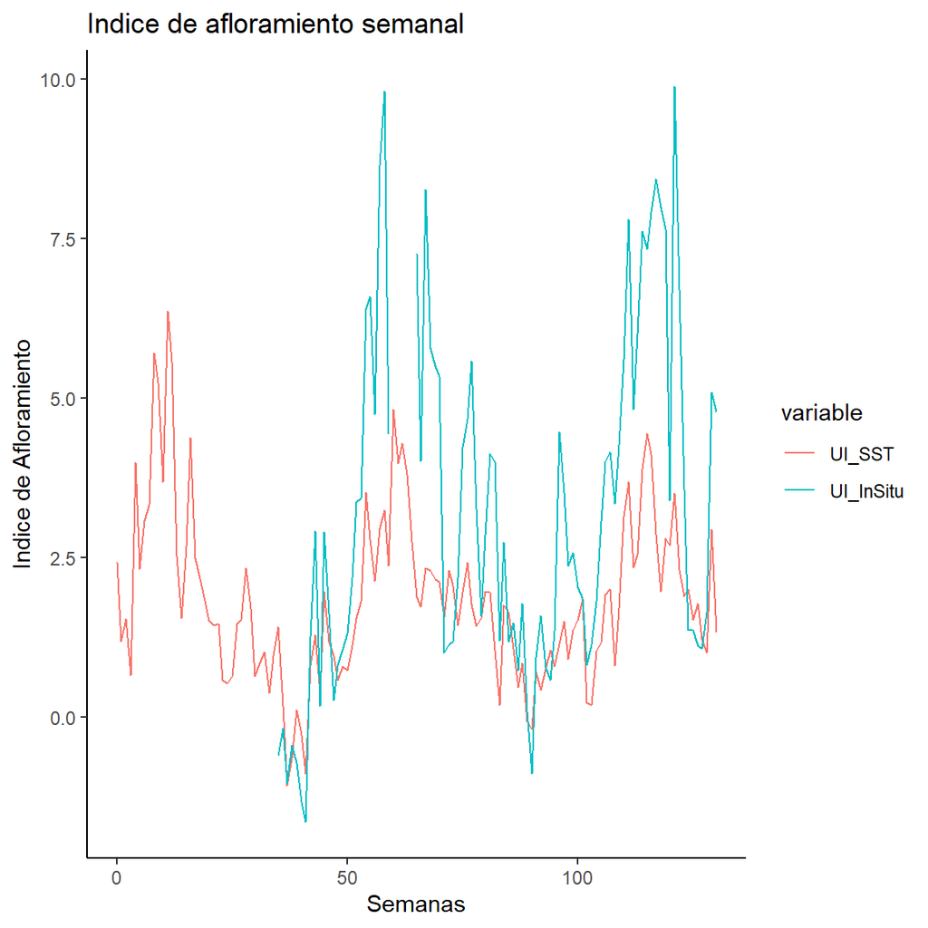

```r
p<- ggplot(wkUI, aes(x = seven_day_index, y = value, colour = variable)) +
  geom_line() +
  labs(title = "Indice de afloramiento semanal") +
  xlab("Semanas")+
  ylab("Indice de Afloramiento")+
  theme(plot.title = element_text(hjust = 0.5))+
  theme_classic()

p
```

Comparar los metodos

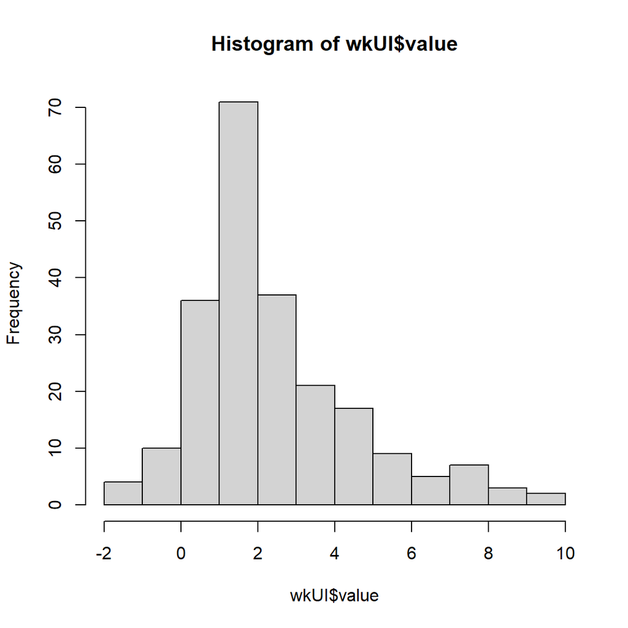

```r
hist(wkUI$value)
```

```r
wwk<-wilcox.test(wkUI$value~wkUI$variable)

wwk
```

```
##
##  Wilcoxon rank sum test with continuity correction
##
## data:  wkUI$value by wkUI$variable
## W = 4338, p-value = 0.0005687
## alternative hypothesis: true location shift is not equal to 0
```

```r
#si hay diferencias significativas entre los dos indices
```

## Indices mensuales

```r
##Unir bases de datos para hacerlas 'tidy'

SSTmUI<-SSTm[,c(1,4)]
colnames(SSTmUI)<-c("month","UI_SST")

TempMUI<-TempM[,c(1,4)]
colnames(TempMUI)<-c("month","UI_InSitu")


mUI<- merge(SSTmUI, TempMUI, all.x=T )
head(mUI)
```

```
##     month   UI_SST UI_InSitu
## 1 01-2018 3.259313        NA
## 2 01-2019 3.523187  6.860688
## 3 01-2020 2.526563  4.661646
## 4 02-2018 5.386688        NA
## 5 02-2019 5.310250 10.278292
## 6 02-2020 3.678500  7.801559
```

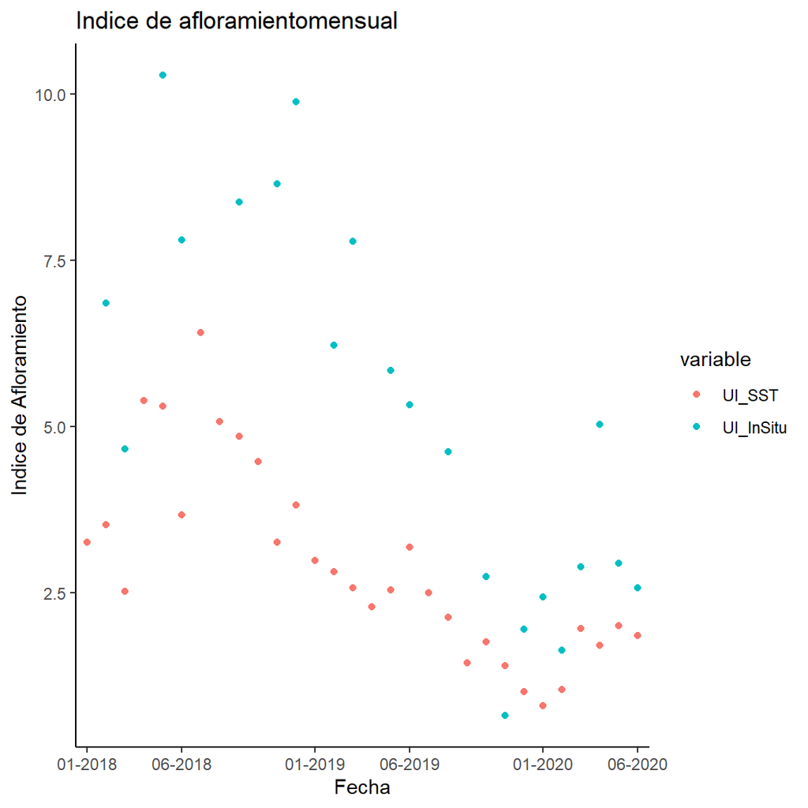

```r
mUI$month<-as.factor(mUI$month)
levels(mUI$month)<-c("01-2018", "02-2018","03-2018", "04-2018", "05-2018", "06-2018",  "07-2018", "08-2018", "09-2018", "10-2018", "11-2018" , "12-2018", "01-2019" , "02-2019","03-2019", "04-2019", "05-2019", "06-2019",  "07-2019", "08-2019", "09-2019", "10-2019", "11-2019" , "12-2019",  "01-2020", "02-2020", "03-2020", "04-2020", "05-2020", "06-2020")

mUI<-reshape2::melt(mUI, id.var = "month")

pp<- ggplot(mUI, aes(x = month, y = value, colour = variable)) +
  geom_point() +
  scale_x_discrete(breaks= c("01-2018", "06-2018", "01-2019" , "06-2019",   "01-2020", "06-2020"))+
  labs(title = "Indice de afloramientomensual") +
  xlab("Fecha")+
  ylab("Indice de Afloramiento")+
  theme(plot.title = element_text(hjust = 0.5))+
  theme_classic()

pp
```

Comparar los metodos

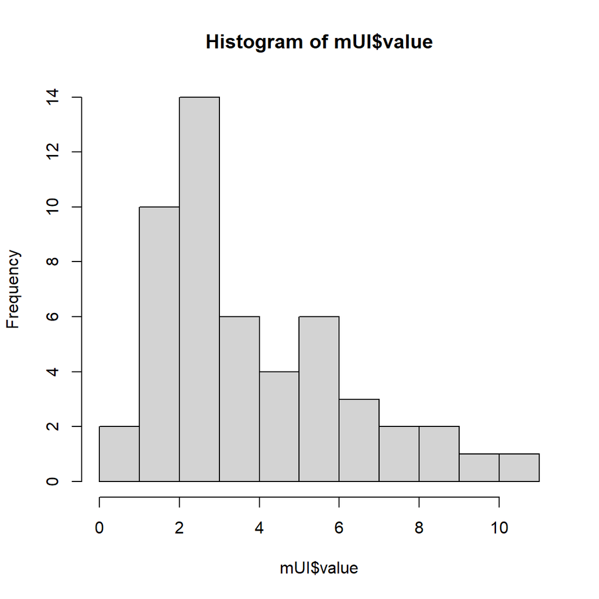

```r
hist(mUI$value)
```

```r
wm<-wilcox.test(mUI$value~mUI$variable)

wm
```

```
##
##  Wilcoxon rank sum exact test
##
## data:  mUI$value by mUI$variable
## W = 168, p-value = 0.004367
## alternative hypothesis: true location shift is not equal to 0
```

```r
#si hay diferencias significativas entre los dos indices
```

# Interpretacion

Los metodos si dieron diferencia entre si, y esto puede ser por varias razones. En primer lugar, la temperatura registrada in situ capta mas la variabilidad diaria de esta variable, ya que se mide todo el dia y noche constantemente, a diferencia de la satelital que solo registra un dato por dia. Ademas, es posible que la escala espacial sea importante, ya que la temperatura in situ representa los datos en un solo punto dentro de la bahia de interes (lo cual puede ser beneficioso), mientras que los satelitales captan un espacio mayor (aprox. 1km a la redonda). Si esta bahia presenta caracteristicas de “refugio” climatico, como sucede en zonas cercanas (comunicacion personal de I. Chaves, estudiante de maestria), entonces el comportamiento de la temperatura dentro de Matapalito puede ser diferente al del poligono de datos satelitales. Aun asi, este procedimiento se debe de volver a repetir cuando se obtengan datos da mas puntos dentro de la bahia (para tener un promedio mas robusto del area). Tambien se puede estandarizar mas el estudio usando datos satelitales que registren la temperatura por hora y usando los datos registrados in situ en esos mismos periodos de tiempo. Si despues de hacer esto, los indices siguen presentando una diferencia significativa, es necesario evaluar cual de los dos metodos brindan informacion mas robusta y adecuada para el analisis de comportamiento espacial que se desea hacer.

Heidemeyer, Maike, Randall Arauz-vargas, and Erick López-agüero. 2014. “New foraging grounds for hawksbill (<i> Eretmochelys imbricata</i> ) and green turtles (<i> Chelonia mydas </i>) along the northern Pacific coast of Costa Rica , Central America.” *Revista de Biologia Tropical* 62 (4): 109–18.

Mortimer, Jeanne A., and M. Donnelly. 2008. “<i>Eretmochelys imbricata</i>.” *The IUCN Red List of Threatened Species*, e.T8005A12881238.